# Data Manipulation with dplyr

C5025HF - Research Methods and Geographical Information Systems

2026-03-12

## Introduction to session

## The problem with data

- Real world data often messy
- Often not collected in tidy formats
- Can slow down analysis and increase frustration

## Messy, untidy data

“Happy families are all alike; every unhappy family is unhappy in its own way.” - Leo Tolstoy

“Tidy datasets are all alike, but every messy dataset is messy in its own way.” - Hadley Wickham

A widely reported observation about analytical work is that data preparation requires a substantial share of the available time:

“Data preparation often accounts for a large majority of analytical work.”

## Common problems with messy data sets

- Column headers are values but should be variable names
- Single column with multiple variables
- Variables entered in both rows and columns
- Multiple types of observational units stored in the same table
- A single observational unit is stored in multiple tables

Examples from: [Hadley Wickham (2014)](https://www.jstatsoft.org/article/view/v059i10)

## Other issues - Excel formatting…

- Merged cells
- Explanatory text (should be elsewhere)
- Unnecessary table *decoration*
- Summary stats/info

## What can untidy data look like?

[figure not shown]

## What can untidy data look like?

[figure not shown]

## Why we don’t want messy data

- Difficult to analyse
- Easy to make mistakes
- Not reproducible

## Messy data might not be perfect, but we can work with it…

But what does “tidy” data look like?

## One *column*: One *variable*

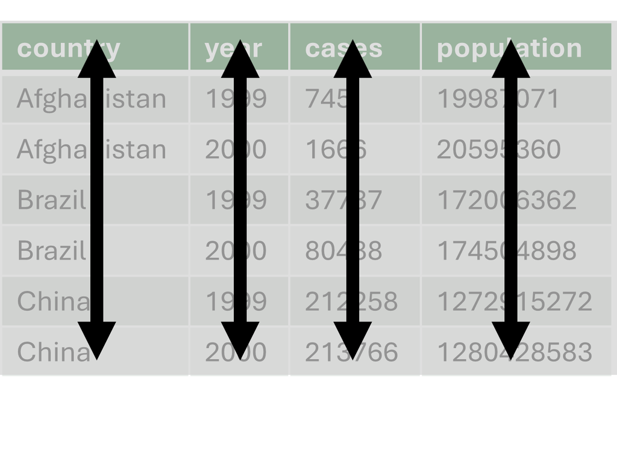

## One *row*: One *observation*

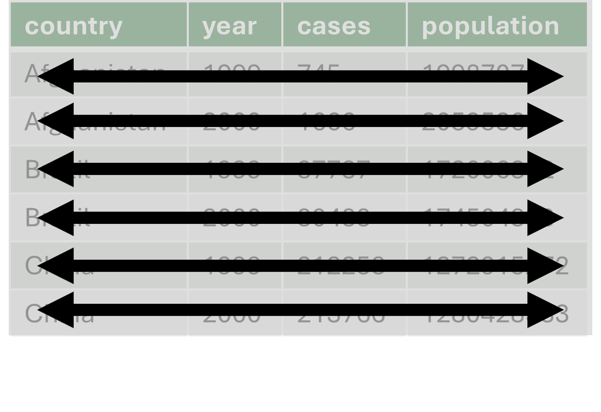

## One *cell*: One *value*

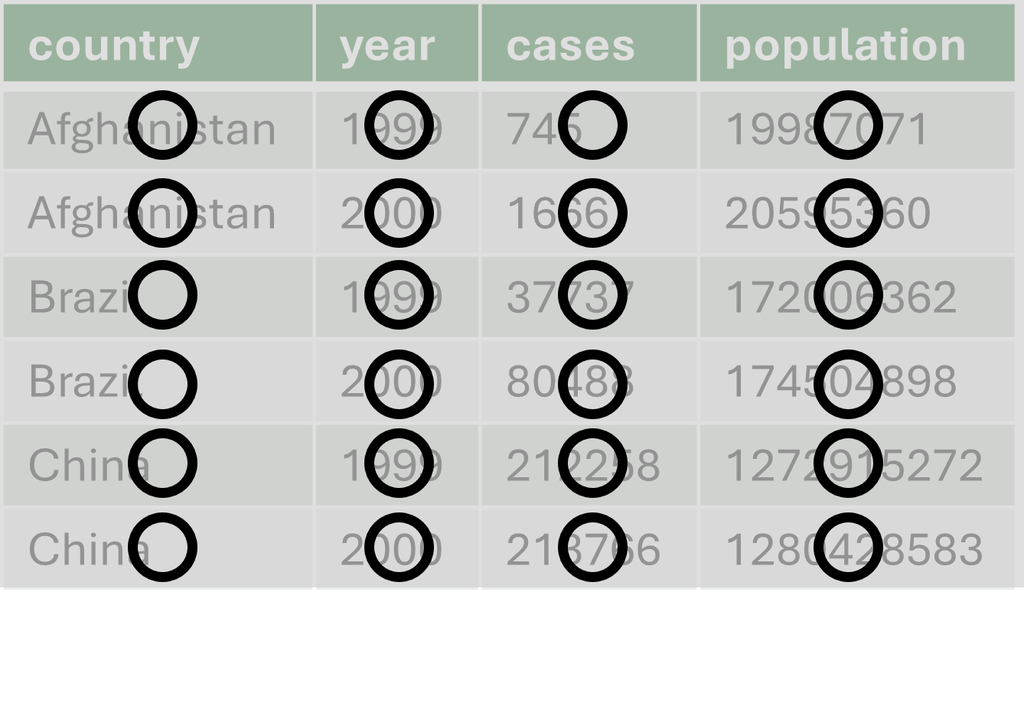

## Tidy data visual example

## Tidy data visual example

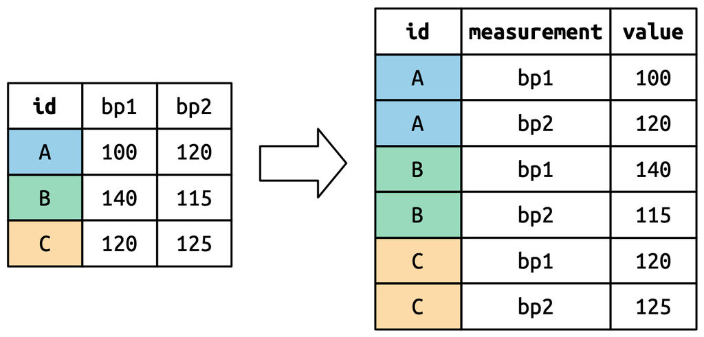

## Tidy data visual example

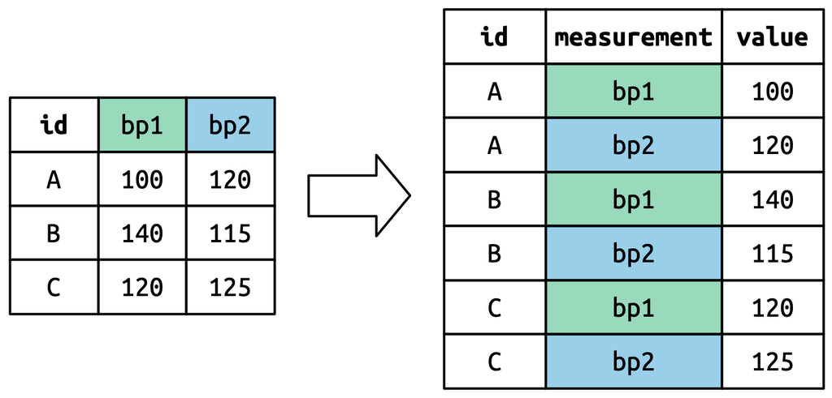

## Tidy data visual example

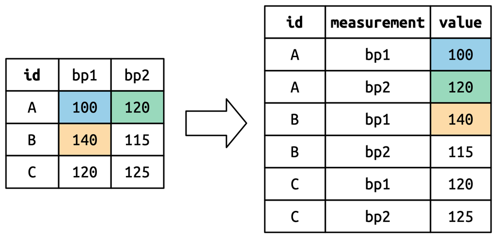

## Why we like ‘tidy’ data

- Easier to wrangle, plot and model
- Gives us a standard structure that works beautifully with the `tidyverse`

## Reflection pause 1

**Pause for reflection.** Use two minutes to consolidate the concept that has just concluded.

- What is the most important idea from the completed section?
- How would you explain that idea in your own words?
- What question would you like to resolve before continuing?

# The Central Idea

Most data analysis can be described as:

## Split -> Apply -> Combine

1. **Split** data into subsets
2. **Apply** a function to each subset
3. **Combine** the results into a structured output

Not a programming trick, but a conceptual framework.

## Split

Partitioning a dataset into meaningful components

E.g., Split by:

- category (e.g. variety, region)
- time interval
- logical condition
- column dimension
- row chunks

Splitting defines structure

## Apply

Performing an operation on each partition independently

E.g., Applying functions like:

- `mean()`, `median()`, `sd()`
- scaling
- thresholding
- modelling
- transformation

The same function is applied to each subset.

## Combine

Reassembling results into a structured object

E.g.,:

- Data frame
- List
- Vector
- Array

The output dimension may differ from the input dimension.

## Reflection pause 2

**Pause for reflection.** Use two minutes to consolidate the concept that has just concluded.

- What is the most important idea from the completed section?
- How would you explain that idea in your own words?
- What question would you like to resolve before continuing?

# Preparing a dataset for analysis

An R toolbox

## The Original `plyr` Design

`plyr` used naming conventions such as:

- `ddply()` — data frame → data frame
- `dlply()` — data frame → list
- `llply()` — list → list

The letters represented:

**Input dimension → Output dimension**

The framework was dimension-agnostic.

## Dramatic entrance from the Tidyverse…

- Collection of R packages for data analysis
- Built around tidy data principles
- Consistent syntax & philosophy

[figure not shown]

## What’s in the Tidyverse?

[figure not shown]

[figure not shown]

Visualize your data

Manipulate your data

Tidy your data

## What’s in the Tidyverse?

[figure not shown]

[figure not shown]

[figure not shown]

Read rectangular data

Work with functions and vectors

Re-imagining the data frame

## What’s in the Tidyverse?

[figure not shown]

[figure not shown]

[figure not shown]

Work with strings

Work with factors

Work with dates and times

## Today’s focus

[figure not shown]

Tidying

Wrangling

## `dplyr` Origins

`dplyr` = **d** (data frames) + **plyr**

- `plyr` was an earlier R package
- Designed as a general tool for manipulating data
- Name inspired by *pliers*: a tool for shaping objects

**The logic of `dplyr`**

Originates from the `split–apply–combine` strategy formalised in:

Wickham (2011), *The Split-Apply-Combine Strategy for Data Analysis*, Journal of Statistical Software.

## Why `dplyr`?

- Data manipulation in the tidyverse
- Consistent, readable grammar
  - First argument is always a data frame
  - Other arguments describe which column to operate on
  - Output always a new data frame
- Works with tibbles and pipes
- Split -> Apply -> Combine philosophy remains the same

## A couple quirks…

The tidyverse can have a couple weird but helpful features…

- Tibbles
- Pipes

## Tibbles

- Special type of data frame used in the tidyverse
- Designed for large datasets
  - Only show the first few rows and columns that fit on one screen
  - can use `View()` to see data in interactive, scrollable and filterable view
  - or `glimpse()` to see all variables in console

## Pipes

- Two forms:
  - Native pipe `|>`
  - `magrittr` package pipe `%>%`
    - (*package loaded as part of tidyverse*)
- Keyboard short cut
  - `ctrl` + `shift` + `m`
  - `cmd` + `shift` + `m`
  - Need to change R settings to use native pipe with shortcut

## Why pipes?

- Takes whats on the left and passes it along to the function on it’s right
- Reduces need for nesting or use of intermediate objects
- Native `|>` vs magrittr `%>%`
  - generally behave identically
  - `%>%` was introduced in 2014 in R
  - `|>` included in R in 2021 but now part of base R

## Quick syntax with and without pipes

No pipe

- `function(data, arguments)`
- Data is first argument
- Function **wraps around** data

With Pipe

- `data |> verb(arguments)`
- Data **flows into** function
- Easier to read and chain multiple steps

## Core `dplyr` verbs

- Each verb does one thing
- Solving complex problems require combining multiple verbs with pipes
- Organised into four groups based on what they operate on:
  - rows
  - columns
  - groups
  - tables

## Core `dplyr` verbs

| Verb | Role in Split–Apply–Combine |
| --- | --- |
| filter() | Reduce rows before split |
| select() | Reduce columns |
| mutate() | Apply function while preserving rows |
| summarise() | Apply function and reduce rows |
| group_by() | Define the split |
| arrange() | Reorder after combine |

## Row verbs

These verbs work across or modify **rows** of your dataset:

- `filter()` – keep only rows that match a condition
- `arrange()` – reorder rows
- `distinct()` – keep only unique rows

## Filtering

dplyr

```r
# Filter to include only humans
starwars |>
  filter(species == "Human")
```

Base R

```r
# Filter using indexing
starwars[starwars$species == "Human", ]
```

## Arranging

dplyr

```r
# Arrange by height in ascending order
starwars |>
  arrange(height)
```

Base R

```r
# Use order() to sort by height
starwars[order(starwars$height), ]
```

## Distinct

dplyr

```r
# Get unique species values in a data frame
starwars |>
  distinct(species)
```

Base R

```r
# To get a data frame equivalent to dplyr
data.frame(species = unique(starwars$species))
```

## Column verbs

These verbs help you work with **columns** of data:

- `mutate()` – create or transform columns
- `select()` – keep/drop columns
- `rename()` – rename columns
- `relocate()` – reorder columns

## Mutate

dplyr

```r
# Create a new column with height in meters
starwars |>
  mutate(height_m = height / 100)
```

Base R

```r
# Same result using base R column creation
starwars$height_m <- starwars$height / 100
```

## Select

dplyr

```r
# Select specific columns
starwars |>
  select(name, species, height)
```

Base R

```r
# Use column indexing
starwars[c("name", "species", "height")]
```

## Rename

dplyr

```r
# Rename the 'name' column
starwars |>
  rename(character_name = name)
```

Base R

```r
# Rename column manually
names(starwars)[names(starwars) == "name"] <- "character_name"
```

## Relocate

dplyr

```r
# Move 'species' before 'name'
starwars |>
  relocate(species, .before = name)
```

Base R

```r
# Reorder columns manually
cols <- names(starwars)
new_order <- c("species", setdiff(cols, "species"))
starwars[new_order]
```

## Group verbs

These verbs are for **grouped operations**, often used in summarising:

- `group_by()` – group dataset by one or more variables
- `summarise()` – calculate summary statistics per group
- `slice_*()` – select specific rows within groups (e.g., `slice_max()`, `slice_head()`)

## Group by & Summarise

dplyr

```r
# Group by species and calculate average height
starwars |>
  group_by(species) |>
  summarise(mean_height = mean(height, na.rm = TRUE))
```

Base R

```r
# Use aggregate to get same result
aggregate(height ~ species, data = starwars, FUN = mean, na.rm = TRUE)
```

## Slice

dplyr

```r
# Take first 3 rows
starwars |>
  slice(1:3)
```

Base R

```r
# Base R equivalent
starwars[1:3, ]
```

## Dimensional structures

Understanding how `dplyr` verbs affect dimensional structure is fundamental.

- `mutate()` preserves row count
- `summarise()` reduces row count
- `filter()` reduces row count
- `pivot_longer()` increases row count
- `pivot_wider()` may reduce row count

Every transformation changes dimensional structure.

## A Data Transformation Recipe

A recipe is:

A reproducible sequence of split–apply–combine operations that converts raw data into structured analytical output.

Structure:

Raw → Clean → Partition → Apply → Combine → Visualise

## The dplyr Pipe and Recipe Flow

A **dplyr recipe** is a *step-by-step transformation* of data

- Each stage passes its result to the next
- The key ingredient for recipe flow is the **pipe** operator (`%>%` or `|>`) which reads as “and then.”

Allows you to express a sequence of operations that mimic your analytic reasoning:

Take raw data, **and then** filter, **and then** group, **and then** summarise, **and then** reshape.

## Anatomy of a `dplyr` Recipe

A typical dplyr transformation has this sequential structure:

```r
data %>%
  filter(...) %>%         # Step 1: Remove unwanted rows
  mutate(...) %>%         # Step 2: Add or modify columns
  group_by(...) %>%       # Step 3: Define partitions
  summarise(...) %>%      # Step 4: Aggregate within partitions
  arrange(...)            # Step 5: Order the results (optional)
```

- Each line is a **verb**, describing what to do at that step.
- The output of one operation becomes the input of the next.
- This sequential flow matches the way you *think* about transforming data.

## Anatomy of a `dplyr` recipe

Pipelines improve **readability** and **reproducibility**

- Makes analysis transparent
- Trace the journey from messy input to structured output

## Piping it all together…

dplyr

```r
starwars |>
  filter(!is.na(mass)) |>         # Remove rows where mass is NA
  group_by(species) |>            # Group data by species
  summarise(avg_mass = mean(mass)) |>  # Mean mass for each species
  arrange(desc(avg_mass))         # Sort results by mean mass, descending
```

Base R

```r
# Filter out NAs
filtered <- starwars[!is.na(starwars$mass), ]

# Mmean mass by species
avg_mass <- aggregate(mass ~ species, data = filtered, FUN = mean)

# Sort descending
avg_mass <- avg_mass[order(-avg_mass$mass), ]
```

## The `tidyr` package

- Help tidy messy data
- Focus on reshaping and reorganizing
- Built around tidy data principles

## `tidyr` functions

- `pivot_longer()`: Reshapes wide data into long format
- `pivot_wider()`: Turns long data into wide format
- `separate()`: Splits one column into multiple based on a delimiter
- `unite()`: Combines multiple columns into one
- `drop_na()` / `replace_na()`: Remove or fill in missing values in a tidy-friendly way

## pivot_longer()

tidyr

```r
# Pivot week columns into long format
billboard_long <- billboard_sm |>
  pivot_longer(
    cols = starts_with("wk"),
    names_to = "week",
    values_to = "rank"
  )
```

Base R

```r
# Reshape wide week columns to long
billboard_long_base <- reshape(
  billboard_sm,
  varying = grep("^wk", names(billboard_sm), value = TRUE),
  v.names = "rank",
  timevar = "week",
  times = grep("^wk", names(billboard_sm), value = TRUE),
  direction = "long"
)
```

## separate()

tidyr

```r
# Split date.entered into components
billboard_sep_date <- billboard_long |>
  separate(date.entered, into = c("year", "month", "day"), sep = "-")
```

Base R

```r
# Use strsplit to separate date into components
date_parts <- do.call(rbind, strsplit(as.character(billboard_long_base$date.entered), "-"))
billboard_long_base$year <- date_parts[, 1]
billboard_long_base$month <- date_parts[, 2]
billboard_long_base$day <- date_parts[, 3]
```

## `dplyr` & `tidyr`: The Big Picture

- Built for readable, transparent and reproducible data transformations
- Expresses workflows with a consistent “verb-based” grammar
- Easy to debug
- Abstracts away implementation details so you can focus on *what* to do, not *how* to do it
- Powers modern, scalable workflows in R—but the conceptual grammar transfers beyond R

## Reflection pause 3

**Pause for reflection.** Use two minutes to consolidate the concept that has just concluded.

- What is the most important idea from the completed section?
- How would you explain that idea in your own words?
- What question would you like to resolve before continuing?

# Lab

## Rotation Lab Overview

Split into 3 groups and rotate across three problems.

Each problem emphasises a different form of splitting:

1. Explicit grouping
2. Dimensional reshaping
3. Conditional partitioning

All datasets are built into `ggplot2`.

## Required packages

```r
library(dplyr)
library(tidyr)
library(ggplot2)

data("diamonds", package = "ggplot2")
data("economics", package = "ggplot2")
data("midwest", package = "ggplot2")
```

# Problem A

## Explicit Group-Based Split

Dataset: `diamonds`

Conceptual focus:

Split by category → Apply summary → Combine → Visualise

## Task A

1. Introduce artificial missing values in `price` and `carat`
2. Remove missing values
3. Cap `price` at 15000 using a threshold
4. Split by `cut`
5. Compute:
   - mean capped price
   - median capped price
   - mean carat
   - count
6. Pipe results into a bar plot

## Task A solution

```r
# Solution for Task A
set.seed(123)  # For reproducibility

diamonds_miss <- diamonds |>
  mutate(
    price = ifelse(runif(n()) < 0.05, NA, price),  # 5% missing in price
    carat = ifelse(runif(n()) < 0.05, NA, carat)   # 5% missing in carat
  ) |>
  filter(!is.na(price), !is.na(carat)) |>
  mutate(price_capped = pmin(price, 15000)) |>
  group_by(cut) |>
  summarise(
    mean_capped_price = mean(price_capped),
    median_capped_price = median(price_capped),
    mean_carat = mean(carat),
    count = n(),
    .groups = "drop"
  ) |>
  ggplot(aes(x = cut, y = mean_capped_price, fill = cut)) +
  geom_col(show.legend = FALSE) +
  labs(
    title = "Mean capped price by cut",
    x = "Cut",
    y = "Mean capped price"
  )
```

## Conceptual Questions

- What variable defines the split?
- Does `mutate()` change row count?
- Does `summarise()` change row count?
- What is the dimension of the combined result?

# Problem B

Dataset: `economics`

Conceptual focus:

Split by time interval and variable dimension.

## Task B

1. Create year and quarter variables from `date`
2. Group by year and quarter and calculate mean of each variable:
   - unemploy
   - uempmed
   - psavert
3. Plot the quarterly average of unemployment

## Problem B Solution

```r
library(dplyr)
library(ggplot2)
library(lubridate)

# Add year and quarter columns
economics_q <- economics %>%
  mutate(
    year = year(date),
    quarter = quarter(date)
  )

# Group by year and quarter, then summarise quarterly means
economics_quarterly <- economics_q %>%
  group_by(year, quarter) %>%
  summarise(
    mean_unemploy = mean(unemploy, na.rm = TRUE),
    mean_uempmed = mean(uempmed, na.rm = TRUE),
    mean_psavert = mean(psavert, na.rm = TRUE),
    .groups = "drop"
  )

# Simple line plot: quarterly unemployment
ggplot(economics_quarterly, aes(x = year + (quarter - 1)/4, y = mean_unemploy)) +
  geom_line(color = "steelblue", size = 1) +
  labs(
    title = "Quarterly Mean Unemployment",
    x = "Year (Quarter)",
    y = "Mean Unemployment"
  )
```

## Conceptual Questions

- Which variables define the time-based split in Task B?
- How does creating year and quarter columns affect the structure of the data?
- Why do we use `group_by(year, quarter)` before summarising?
- What does summarising multiple variables together achieve in this context?
- How does this example illustrate split–apply–combine over time?

# Problem C

## Conditional Partitioning

Dataset: `midwest`

Conceptual focus:

Splitting via logical classification.

## Task C

Goal: Compare average population density by poverty status, across states.

1. Create a simple poverty band: “Low” if poverty < 15%, otherwise “High”
2. Group by state and poverty band
3. Compute average population density for each group

## Problem C Solution

```r
library(dplyr)
library(ggplot2)

# Add a poverty band with mutate, then group and summarise
midwest_summary <- midwest %>%
  mutate(
    poverty_band = ifelse(poverty < 15, "Low", "High")
  ) %>%
  group_by(state, poverty_band) %>%
  summarise(
    mean_density = mean(poptotal / area, na.rm = TRUE)
  )

# Visualise
ggplot(midwest_summary, aes(x = poverty_band, y = mean_density, fill = poverty_band)) +
  geom_col() +
  facet_wrap(~state) +
  labs(
    title = "Mean Population Density by Poverty Band and State",
    x = "Poverty Band",
    y = "Mean Population Density"
  ) +
  theme_minimal() +
  theme(legend.position = "none")
```

## Conceptual Questions

- What does `mutate()` add to your data here?
- What variable(s) define the data split for the summary?
- Why do we use `group_by()` before `summarise()`?

## Further exploration

Let’s explore a more advanced transformation using `filter`, grouped summaries, and visualisation.

Goal: For each state and poverty band, calculate:

- **mean** of population density
- **standard deviation** of population density
- **for counties with population over 10,000**
- visualise the results with error bars.

## Further exploration

```r
library(dplyr)
library(ggplot2)

midwest_stats <- midwest %>%
  filter(poptotal > 10000) %>%
  mutate(
    poverty_band = ifelse(poverty < 15, "Low", "High"),
    pop_density = poptotal / area
  ) %>%
  group_by(state, poverty_band) %>%
  summarise(
    mean_density = mean(pop_density, na.rm = TRUE),
    sd_density = sd(pop_density, na.rm = TRUE),
    .groups = "drop"
  )
```

## Further exploration

```r
# Visualise mean ± SD with pointrange
ggplot(midwest_stats, aes(x = poverty_band, y = mean_density, ymin = mean_density - sd_density, ymax = mean_density + sd_density, color = poverty_band)) +
  geom_pointrange(position = position_dodge(width = 0.5)) +
  facet_wrap(~state) +
  labs(
    title = "Population Density (Mean ± SD) by Poverty Band and State (Counties > 10,000 pop.)",
    x = "Poverty Band",
    y = "Population Density"
  ) +
  theme_minimal() +
  theme(legend.position = "none")
```

## Reflection

Consider:

- What defines a partition?
- What determines output dimensionality?
- Why does operation order matter?
- How does `dplyr` encode split–apply–combine?

## Key Takeaways

- `dplyr` & `tidyr` use `tidyverse` grammar for structured data manipulation
- Dimensional changes are deliberate and traceable
- Pipes: build readable, step-by-step workflows
- Small, simple verbs — like filter(), mutate(), group_by() — combine to solve complex problems
- Split–apply–combine is the unifying principle

## Additional Resources

- [Hadley Wickham (2014)](https://www.jstatsoft.org/article/view/v059i10)
- [Tidyverse documentation](https://www.tidyverse.org/)
- [R Studio cheat sheets](https://posit.co/resources/cheatsheets/)